# Risk Factor Analysis

## Outcome Variable

**Outcome Variable:** y_rate_len

## Predictor Variables

**Intervention Variable:** trth2o

**Adjustment Set:**

- arm
- sex
- W_mage
- meducyrs
- feducyrs
- hhwealth_quart
- hfoodsec
- W_mhtcm
- W_mwtkg
- W_mbmi
- W_nrooms
- W_nhh
- W_nchldlt5
- brthmon
- cleanck
- impfloor
- impsan
- safeh20
- delta_meducyrs
- delta_feducyrs
- delta_hhwealth_quart
- delta_hfoodsec
- delta_W_mhtcm
- delta_W_mwtkg
- delta_W_mbmi
- delta_W_nrooms
- delta_W_nhh
- delta_W_nchldlt5
- delta_brthmon
- delta_cleanck
- delta_impfloor
- delta_impsan
- delta_safeh20

## Stratifying Variables

The analysis was stratified on these variable(s):

- agecat
- studyid
- country

## Data Summary

| agecat | studyid | country | trth2o | n_cell | n |
| --- | --- | --- | --- | --- | --- |
| 0-3 months | CMC-V-BCS-2002 | INDIA | 1 | 25 | 25 |
| 0-3 months | CMC-V-BCS-2002 | INDIA | 0 | 0 | 25 |
| 0-3 months | GMS-Nepal | NEPAL | 1 | 1 | 4 |
| 0-3 months | GMS-Nepal | NEPAL | 0 | 3 | 4 |
| 0-3 months | IRC | INDIA | 1 | 118 | 118 |
| 0-3 months | IRC | INDIA | 0 | 0 | 118 |
| 0-3 months | MAL-ED | BANGLADESH | 1 | 132 | 134 |
| 0-3 months | MAL-ED | BANGLADESH | 0 | 2 | 134 |
| 0-3 months | MAL-ED | BRAZIL | 1 | 11 | 82 |
| 0-3 months | MAL-ED | BRAZIL | 0 | 71 | 82 |
| 0-3 months | MAL-ED | INDIA | 1 | 2 | 5 |
| 0-3 months | MAL-ED | INDIA | 0 | 3 | 5 |
| 0-3 months | MAL-ED | NEPAL | 1 | 45 | 55 |
| 0-3 months | MAL-ED | NEPAL | 0 | 10 | 55 |
| 0-3 months | MAL-ED | PERU | 1 | 36 | 45 |
| 0-3 months | MAL-ED | PERU | 0 | 9 | 45 |
| 0-3 months | MAL-ED | SOUTH AFRICA | 1 | 1 | 9 |
| 0-3 months | MAL-ED | SOUTH AFRICA | 0 | 8 | 9 |
| 0-3 months | MAL-ED | TANZANIA, UNITED REPUBLIC OF | 1 | 6 | 38 |
| 0-3 months | MAL-ED | TANZANIA, UNITED REPUBLIC OF | 0 | 32 | 38 |
| 0-3 months | NIH-Crypto | BANGLADESH | 1 | 402 | 721 |
| 0-3 months | NIH-Crypto | BANGLADESH | 0 | 319 | 721 |
| 0-3 months | PROVIDE | BANGLADESH | 1 | 14 | 640 |
| 0-3 months | PROVIDE | BANGLADESH | 0 | 626 | 640 |
| 3-6 months | CMC-V-BCS-2002 | INDIA | 1 | 101 | 101 |
| 3-6 months | CMC-V-BCS-2002 | INDIA | 0 | 0 | 101 |
| 3-6 months | GMS-Nepal | NEPAL | 1 | 1 | 4 |
| 3-6 months | GMS-Nepal | NEPAL | 0 | 3 | 4 |
| 3-6 months | IRC | INDIA | 1 | 119 | 119 |
| 3-6 months | IRC | INDIA | 0 | 0 | 119 |

[output cut: 162 more lines]

The following strata were considered:

- agecat: 0-3 months, studyid: CMC-V-BCS-2002, country: INDIA
- agecat: 0-3 months, studyid: GMS-Nepal, country: NEPAL
- agecat: 0-3 months, studyid: IRC, country: INDIA
- agecat: 0-3 months, studyid: MAL-ED, country: BANGLADESH
- agecat: 0-3 months, studyid: MAL-ED, country: BRAZIL
- agecat: 0-3 months, studyid: MAL-ED, country: INDIA
- agecat: 0-3 months, studyid: MAL-ED, country: NEPAL
- agecat: 0-3 months, studyid: MAL-ED, country: PERU
- agecat: 0-3 months, studyid: MAL-ED, country: SOUTH AFRICA
- agecat: 0-3 months, studyid: MAL-ED, country: TANZANIA, UNITED REPUBLIC OF
- agecat: 0-3 months, studyid: NIH-Crypto, country: BANGLADESH
- agecat: 0-3 months, studyid: PROVIDE, country: BANGLADESH
- agecat: 12-15 months, studyid: CMC-V-BCS-2002, country: INDIA
- agecat: 12-15 months, studyid: GMS-Nepal, country: NEPAL
- agecat: 12-15 months, studyid: IRC, country: INDIA
- agecat: 12-15 months, studyid: MAL-ED, country: BANGLADESH
- agecat: 12-15 months, studyid: MAL-ED, country: BRAZIL
- agecat: 12-15 months, studyid: MAL-ED, country: INDIA
- agecat: 12-15 months, studyid: MAL-ED, country: NEPAL
- agecat: 12-15 months, studyid: MAL-ED, country: PERU
- agecat: 12-15 months, studyid: MAL-ED, country: SOUTH AFRICA
- agecat: 12-15 months, studyid: MAL-ED, country: TANZANIA, UNITED REPUBLIC OF
- agecat: 12-15 months, studyid: NIH-Crypto, country: BANGLADESH
- agecat: 12-15 months, studyid: PROVIDE, country: BANGLADESH
- agecat: 15-18 months, studyid: CMC-V-BCS-2002, country: INDIA
- agecat: 15-18 months, studyid: GMS-Nepal, country: NEPAL
- agecat: 15-18 months, studyid: IRC, country: INDIA
- agecat: 15-18 months, studyid: MAL-ED, country: BANGLADESH
- agecat: 15-18 months, studyid: MAL-ED, country: BRAZIL
- agecat: 15-18 months, studyid: MAL-ED, country: INDIA
- agecat: 15-18 months, studyid: MAL-ED, country: NEPAL
- agecat: 15-18 months, studyid: MAL-ED, country: PERU
- agecat: 15-18 months, studyid: MAL-ED, country: SOUTH AFRICA
- agecat: 15-18 months, studyid: MAL-ED, country: TANZANIA, UNITED REPUBLIC OF
- agecat: 15-18 months, studyid: NIH-Crypto, country: BANGLADESH
- agecat: 15-18 months, studyid: PROVIDE, country: BANGLADESH
- agecat: 18-21 months, studyid: CMC-V-BCS-2002, country: INDIA
- agecat: 18-21 months, studyid: GMS-Nepal, country: NEPAL
- agecat: 18-21 months, studyid: IRC, country: INDIA
- agecat: 18-21 months, studyid: MAL-ED, country: BANGLADESH
- agecat: 18-21 months, studyid: MAL-ED, country: BRAZIL
- agecat: 18-21 months, studyid: MAL-ED, country: INDIA
- agecat: 18-21 months, studyid: MAL-ED, country: NEPAL
- agecat: 18-21 months, studyid: MAL-ED, country: PERU
- agecat: 18-21 months, studyid: MAL-ED, country: SOUTH AFRICA
- agecat: 18-21 months, studyid: MAL-ED, country: TANZANIA, UNITED REPUBLIC OF
- agecat: 18-21 months, studyid: NIH-Crypto, country: BANGLADESH
- agecat: 18-21 months, studyid: PROVIDE, country: BANGLADESH
- agecat: 21-24 months, studyid: CMC-V-BCS-2002, country: INDIA
- agecat: 21-24 months, studyid: GMS-Nepal, country: NEPAL
- agecat: 21-24 months, studyid: IRC, country: INDIA
- agecat: 21-24 months, studyid: MAL-ED, country: BANGLADESH
- agecat: 21-24 months, studyid: MAL-ED, country: BRAZIL
- agecat: 21-24 months, studyid: MAL-ED, country: INDIA
- agecat: 21-24 months, studyid: MAL-ED, country: NEPAL
- agecat: 21-24 months, studyid: MAL-ED, country: PERU
- agecat: 21-24 months, studyid: MAL-ED, country: SOUTH AFRICA
- agecat: 21-24 months, studyid: MAL-ED, country: TANZANIA, UNITED REPUBLIC OF
- agecat: 21-24 months, studyid: NIH-Crypto, country: BANGLADESH
- agecat: 21-24 months, studyid: PROVIDE, country: BANGLADESH
- agecat: 3-6 months, studyid: CMC-V-BCS-2002, country: INDIA
- agecat: 3-6 months, studyid: GMS-Nepal, country: NEPAL
- agecat: 3-6 months, studyid: IRC, country: INDIA
- agecat: 3-6 months, studyid: MAL-ED, country: BANGLADESH
- agecat: 3-6 months, studyid: MAL-ED, country: BRAZIL
- agecat: 3-6 months, studyid: MAL-ED, country: INDIA
- agecat: 3-6 months, studyid: MAL-ED, country: NEPAL
- agecat: 3-6 months, studyid: MAL-ED, country: PERU
- agecat: 3-6 months, studyid: MAL-ED, country: SOUTH AFRICA
- agecat: 3-6 months, studyid: MAL-ED, country: TANZANIA, UNITED REPUBLIC OF
- agecat: 3-6 months, studyid: NIH-Crypto, country: BANGLADESH
- agecat: 3-6 months, studyid: PROVIDE, country: BANGLADESH
- agecat: 6-9 months, studyid: CMC-V-BCS-2002, country: INDIA
- agecat: 6-9 months, studyid: GMS-Nepal, country: NEPAL
- agecat: 6-9 months, studyid: IRC, country: INDIA
- agecat: 6-9 months, studyid: MAL-ED, country: BANGLADESH
- agecat: 6-9 months, studyid: MAL-ED, country: BRAZIL
- agecat: 6-9 months, studyid: MAL-ED, country: INDIA
- agecat: 6-9 months, studyid: MAL-ED, country: NEPAL
- agecat: 6-9 months, studyid: MAL-ED, country: PERU
- agecat: 6-9 months, studyid: MAL-ED, country: SOUTH AFRICA
- agecat: 6-9 months, studyid: MAL-ED, country: TANZANIA, UNITED REPUBLIC OF
- agecat: 6-9 months, studyid: NIH-Crypto, country: BANGLADESH
- agecat: 6-9 months, studyid: PROVIDE, country: BANGLADESH
- agecat: 9-12 months, studyid: CMC-V-BCS-2002, country: INDIA
- agecat: 9-12 months, studyid: GMS-Nepal, country: NEPAL
- agecat: 9-12 months, studyid: IRC, country: INDIA
- agecat: 9-12 months, studyid: MAL-ED, country: BANGLADESH
- agecat: 9-12 months, studyid: MAL-ED, country: BRAZIL
- agecat: 9-12 months, studyid: MAL-ED, country: INDIA
- agecat: 9-12 months, studyid: MAL-ED, country: NEPAL
- agecat: 9-12 months, studyid: MAL-ED, country: PERU
- agecat: 9-12 months, studyid: MAL-ED, country: SOUTH AFRICA
- agecat: 9-12 months, studyid: MAL-ED, country: TANZANIA, UNITED REPUBLIC OF
- agecat: 9-12 months, studyid: NIH-Crypto, country: BANGLADESH
- agecat: 9-12 months, studyid: PROVIDE, country: BANGLADESH

### Dropped Strata

- agecat: 0-3 months, studyid: CMC-V-BCS-2002, country: INDIA
- agecat: 0-3 months, studyid: GMS-Nepal, country: NEPAL
- agecat: 0-3 months, studyid: IRC, country: INDIA
- agecat: 0-3 months, studyid: MAL-ED, country: BANGLADESH
- agecat: 0-3 months, studyid: MAL-ED, country: INDIA
- agecat: 0-3 months, studyid: MAL-ED, country: SOUTH AFRICA
- agecat: 3-6 months, studyid: CMC-V-BCS-2002, country: INDIA
- agecat: 3-6 months, studyid: GMS-Nepal, country: NEPAL
- agecat: 3-6 months, studyid: IRC, country: INDIA
- agecat: 3-6 months, studyid: MAL-ED, country: BANGLADESH
- agecat: 3-6 months, studyid: MAL-ED, country: INDIA
- agecat: 3-6 months, studyid: MAL-ED, country: SOUTH AFRICA
- agecat: 6-9 months, studyid: CMC-V-BCS-2002, country: INDIA
- agecat: 6-9 months, studyid: GMS-Nepal, country: NEPAL
- agecat: 6-9 months, studyid: IRC, country: INDIA
- agecat: 6-9 months, studyid: MAL-ED, country: BANGLADESH
- agecat: 6-9 months, studyid: MAL-ED, country: INDIA
- agecat: 6-9 months, studyid: MAL-ED, country: SOUTH AFRICA
- agecat: 9-12 months, studyid: CMC-V-BCS-2002, country: INDIA
- agecat: 9-12 months, studyid: GMS-Nepal, country: NEPAL
- agecat: 9-12 months, studyid: IRC, country: INDIA
- agecat: 9-12 months, studyid: MAL-ED, country: BANGLADESH
- agecat: 9-12 months, studyid: MAL-ED, country: INDIA
- agecat: 9-12 months, studyid: MAL-ED, country: SOUTH AFRICA
- agecat: 12-15 months, studyid: CMC-V-BCS-2002, country: INDIA
- agecat: 12-15 months, studyid: GMS-Nepal, country: NEPAL
- agecat: 12-15 months, studyid: IRC, country: INDIA
- agecat: 12-15 months, studyid: MAL-ED, country: BANGLADESH
- agecat: 12-15 months, studyid: MAL-ED, country: INDIA
- agecat: 12-15 months, studyid: MAL-ED, country: SOUTH AFRICA
- agecat: 15-18 months, studyid: CMC-V-BCS-2002, country: INDIA
- agecat: 15-18 months, studyid: GMS-Nepal, country: NEPAL
- agecat: 15-18 months, studyid: IRC, country: INDIA
- agecat: 15-18 months, studyid: MAL-ED, country: BANGLADESH
- agecat: 15-18 months, studyid: MAL-ED, country: INDIA
- agecat: 15-18 months, studyid: MAL-ED, country: SOUTH AFRICA
- agecat: 18-21 months, studyid: CMC-V-BCS-2002, country: INDIA
- agecat: 18-21 months, studyid: GMS-Nepal, country: NEPAL
- agecat: 18-21 months, studyid: IRC, country: INDIA
- agecat: 18-21 months, studyid: MAL-ED, country: BANGLADESH
- agecat: 18-21 months, studyid: MAL-ED, country: INDIA
- agecat: 18-21 months, studyid: MAL-ED, country: SOUTH AFRICA
- agecat: 21-24 months, studyid: CMC-V-BCS-2002, country: INDIA
- agecat: 21-24 months, studyid: GMS-Nepal, country: NEPAL
- agecat: 21-24 months, studyid: IRC, country: INDIA
- agecat: 21-24 months, studyid: MAL-ED, country: BANGLADESH
- agecat: 21-24 months, studyid: MAL-ED, country: INDIA
- agecat: 21-24 months, studyid: MAL-ED, country: SOUTH AFRICA

## Methods Detail

We’re interested in the causal parameters $E[Y_a]$ for all values of $a \in \mathcal{A}$. These parameters represent the mean outcome if, possibly contrary to fact, we intervened to set all units to have $A=a$. Under the randomization and positivity assumptions, these are identified by the statistical parameters $\psi_a=E_W[E_{Y|A,W}(Y|A=a,W)]$. In addition, we’re interested in the mean of $Y$, $E[Y]$ under no intervention (the observed mean). We will estimate these parameters by using SuperLearner to fit the relevant likelihood factors – $E_{Y|A,W}(Y|A=a,W)$ and $p(A=a|W)$, and then updating our likelihood fit using a joint TMLE.

For unadjusted analyses ($W=\{\}$), initial likelihoods were estimated using Lrnr_glm to estimate the simple $E(Y|A)$ and Lrnr_mean to estimate $p(A)$. For adjusted analyses, a small library containing Lrnr_glmnet, Lrnr_xgboost, and Lrnr_mean was used.

Having estimated these parameters, we will then use the delta method to estimate relative risks and attributable risks relative to a prespecified baseline level of $A$.

# Results Detail

## Results Plots

[figure not shown]

[figure not shown]

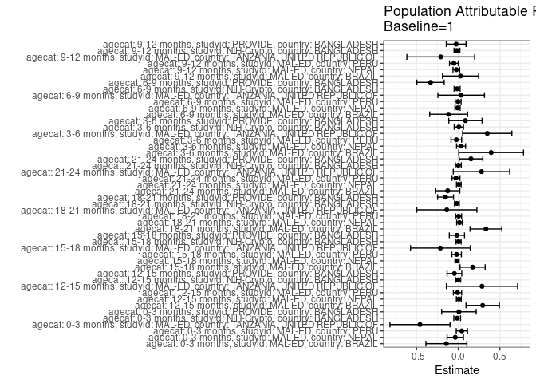

## Results Table

### Parameter: TSM

| agecat | studyid | country | intervention_level | baseline_level | estimate | ci_lower | ci_upper |
| --- | --- | --- | --- | --- | --- | --- | --- |
| 0-3 months | MAL-ED | BRAZIL | 1 | NA | 4.0012388 | 3.7710096 | 4.2314680 |
| 0-3 months | MAL-ED | BRAZIL | 0 | NA | 3.8262903 | 3.6682723 | 3.9843084 |
| 0-3 months | MAL-ED | NEPAL | 1 | NA | 3.5385726 | 3.3765899 | 3.7005553 |
| 0-3 months | MAL-ED | NEPAL | 0 | NA | 3.3148613 | 2.7809329 | 3.8487898 |
| 0-3 months | MAL-ED | PERU | 1 | NA | 3.0273565 | 2.8251714 | 3.2295415 |
| 0-3 months | MAL-ED | PERU | 0 | NA | 3.2438992 | 3.0076078 | 3.4801905 |
| 0-3 months | MAL-ED | TANZANIA, UNITED REPUBLIC OF | 1 | NA | 3.4897230 | 3.1171369 | 3.8623092 |
| 0-3 months | MAL-ED | TANZANIA, UNITED REPUBLIC OF | 0 | NA | 2.9447033 | 2.7483050 | 3.1411017 |
| 0-3 months | NIH-Crypto | BANGLADESH | 1 | NA | 3.1420570 | 3.0848719 | 3.1992420 |
| 0-3 months | NIH-Crypto | BANGLADESH | 0 | NA | 3.1143138 | 3.0473414 | 3.1812862 |
| 0-3 months | PROVIDE | BANGLADESH | 1 | NA | 3.2493667 | 3.0405248 | 3.4582085 |
| 0-3 months | PROVIDE | BANGLADESH | 0 | NA | 3.2581891 | 3.2205459 | 3.2958323 |
| 3-6 months | MAL-ED | BRAZIL | 1 | NA | 1.8252644 | 1.4018015 | 2.2487274 |
| 3-6 months | MAL-ED | BRAZIL | 0 | NA | 2.2444780 | 2.1353350 | 2.3536210 |
| 3-6 months | MAL-ED | NEPAL | 1 | NA | 1.9513702 | 1.8417423 | 2.0609982 |
| 3-6 months | MAL-ED | NEPAL | 0 | NA | 2.1592878 | 1.8654537 | 2.4531220 |
| 3-6 months | MAL-ED | PERU | 1 | NA | 2.0290268 | 1.8501439 | 2.2079096 |
| 3-6 months | MAL-ED | PERU | 0 | NA | 1.9866015 | 1.7191126 | 2.2540904 |
| 3-6 months | MAL-ED | TANZANIA, UNITED REPUBLIC OF | 1 | NA | 1.4680424 | 1.1592662 | 1.7768187 |
| 3-6 months | MAL-ED | TANZANIA, UNITED REPUBLIC OF | 0 | NA | 1.8739708 | 1.7296439 | 2.0182977 |
| 3-6 months | NIH-Crypto | BANGLADESH | 1 | NA | 1.9987745 | 1.9292958 | 2.0682532 |
| 3-6 months | NIH-Crypto | BANGLADESH | 0 | NA | 2.0288290 | 1.9694274 | 2.0882306 |
| 3-6 months | PROVIDE | BANGLADESH | 1 | NA | 1.8795950 | 1.6784831 | 2.0807069 |
| 3-6 months | PROVIDE | BANGLADESH | 0 | NA | 1.9712019 | 1.9369053 | 2.0054985 |
| 6-9 months | MAL-ED | BRAZIL | 1 | NA | 1.6573573 | 1.4372895 | 1.8774251 |
| 6-9 months | MAL-ED | BRAZIL | 0 | NA | 1.5424843 | 1.4023976 | 1.6825710 |
| 6-9 months | MAL-ED | NEPAL | 1 | NA | 1.3199104 | 1.2372481 | 1.4025727 |
| 6-9 months | MAL-ED | NEPAL | 0 | NA | 1.2830528 | 1.0940327 | 1.4720729 |
| 6-9 months | MAL-ED | PERU | 1 | NA | 1.1954387 | 1.0586810 | 1.3321964 |
| 6-9 months | MAL-ED | PERU | 0 | NA | 1.0437360 | 0.9417670 | 1.1457050 |

[output cut: 66 more lines]

### Parameter: E(Y)

| agecat | studyid | country | intervention_level | baseline_level | estimate | ci_lower | ci_upper |
| --- | --- | --- | --- | --- | --- | --- | --- |
| 0-3 months | MAL-ED | BRAZIL | NA | NA | 3.8592466 | 3.7187660 | 3.9997272 |
| 0-3 months | MAL-ED | NEPAL | NA | NA | 3.5026449 | 3.3476789 | 3.6576109 |
| 0-3 months | MAL-ED | PERU | NA | NA | 3.0706650 | 2.9002220 | 3.2411079 |
| 0-3 months | MAL-ED | TANZANIA, UNITED REPUBLIC OF | NA | NA | 3.0307591 | 2.8439041 | 3.2176140 |
| 0-3 months | NIH-Crypto | BANGLADESH | NA | NA | 3.1292449 | 3.0928504 | 3.1656393 |
| 0-3 months | PROVIDE | BANGLADESH | NA | NA | 3.2576810 | 3.2206777 | 3.2946843 |
| 3-6 months | MAL-ED | BRAZIL | NA | NA | 2.2197131 | 2.1101066 | 2.3293196 |
| 3-6 months | MAL-ED | NEPAL | NA | NA | 1.9853011 | 1.8803268 | 2.0902754 |
| 3-6 months | MAL-ED | PERU | NA | NA | 2.0060188 | 1.8634433 | 2.1485943 |
| 3-6 months | MAL-ED | TANZANIA, UNITED REPUBLIC OF | NA | NA | 1.8159811 | 1.6776334 | 1.9543288 |
| 3-6 months | NIH-Crypto | BANGLADESH | NA | NA | 2.0057973 | 1.9693775 | 2.0422170 |
| 3-6 months | PROVIDE | BANGLADESH | NA | NA | 1.9657457 | 1.9318660 | 1.9996254 |
| 6-9 months | MAL-ED | BRAZIL | NA | NA | 1.5419552 | 1.4161616 | 1.6677488 |
| 6-9 months | MAL-ED | NEPAL | NA | NA | 1.3116074 | 1.2397407 | 1.3834741 |
| 6-9 months | MAL-ED | PERU | NA | NA | 1.1939434 | 1.0843398 | 1.3035471 |
| 6-9 months | MAL-ED | TANZANIA, UNITED REPUBLIC OF | NA | NA | 1.2629098 | 0.9955016 | 1.5303180 |
| 6-9 months | NIH-Crypto | BANGLADESH | NA | NA | 1.3282695 | 1.2988292 | 1.3577098 |
| 6-9 months | PROVIDE | BANGLADESH | NA | NA | 1.2824185 | 1.2571827 | 1.3076542 |
| 9-12 months | MAL-ED | BRAZIL | NA | NA | 1.2896896 | 1.1901580 | 1.3892213 |
| 9-12 months | MAL-ED | NEPAL | NA | NA | 1.0747092 | 1.0020180 | 1.1474004 |
| 9-12 months | MAL-ED | PERU | NA | NA | 1.1281439 | 1.0053147 | 1.2509730 |
| 9-12 months | MAL-ED | TANZANIA, UNITED REPUBLIC OF | NA | NA | 0.8117127 | 0.5485045 | 1.0749209 |
| 9-12 months | NIH-Crypto | BANGLADESH | NA | NA | 1.1234745 | 1.0972274 | 1.1497215 |
| 9-12 months | PROVIDE | BANGLADESH | NA | NA | 1.0499750 | 1.0230130 | 1.0769370 |
| 12-15 months | MAL-ED | BRAZIL | NA | NA | 1.1769612 | 1.1045524 | 1.2493699 |
| 12-15 months | MAL-ED | NEPAL | NA | NA | 1.0278956 | 0.9678283 | 1.0879630 |
| 12-15 months | MAL-ED | PERU | NA | NA | 0.8783001 | 0.7638220 | 0.9927782 |
| 12-15 months | MAL-ED | TANZANIA, UNITED REPUBLIC OF | NA | NA | 0.7956749 | 0.6519279 | 0.9394219 |
| 12-15 months | NIH-Crypto | BANGLADESH | NA | NA | 0.9711395 | 0.9465805 | 0.9956985 |
| 12-15 months | PROVIDE | BANGLADESH | NA | NA | 0.9597501 | 0.9335899 | 0.9859102 |
| 15-18 months | MAL-ED | BRAZIL | NA | NA | 1.0078031 | 0.9251335 | 1.0904728 |
| 15-18 months | MAL-ED | NEPAL | NA | NA | 0.8737133 | 0.8117853 | 0.9356414 |
| 15-18 months | MAL-ED | PERU | NA | NA | 0.8383703 | 0.7329602 | 0.9437805 |
| 15-18 months | MAL-ED | TANZANIA, UNITED REPUBLIC OF | NA | NA | 0.7647144 | 0.6223905 | 0.9070384 |
| 15-18 months | NIH-Crypto | BANGLADESH | NA | NA | 0.9177168 | 0.8947657 | 0.9406678 |
| 15-18 months | PROVIDE | BANGLADESH | NA | NA | 0.8560998 | 0.8320145 | 0.8801852 |
| 18-21 months | MAL-ED | BRAZIL | NA | NA | 0.9113468 | 0.8087233 | 1.0139703 |
| 18-21 months | MAL-ED | NEPAL | NA | NA | 0.7759274 | 0.7112362 | 0.8406186 |
| 18-21 months | MAL-ED | PERU | NA | NA | 0.8457955 | 0.7602887 | 0.9313023 |
| 18-21 months | MAL-ED | TANZANIA, UNITED REPUBLIC OF | NA | NA | 0.6129126 | 0.4646003 | 0.7612249 |
| 18-21 months | NIH-Crypto | BANGLADESH | NA | NA | 0.7977755 | 0.7744353 | 0.8211158 |
| 18-21 months | PROVIDE | BANGLADESH | NA | NA | 0.8393377 | 0.8153485 | 0.8633269 |
| 21-24 months | MAL-ED | BRAZIL | NA | NA | 0.7722472 | 0.7221195 | 0.8223749 |
| 21-24 months | MAL-ED | NEPAL | NA | NA | 0.7915700 | 0.7335331 | 0.8496069 |
| 21-24 months | MAL-ED | PERU | NA | NA | 0.7989125 | 0.7024314 | 0.8953937 |
| 21-24 months | MAL-ED | TANZANIA, UNITED REPUBLIC OF | NA | NA | 0.7040721 | 0.5679942 | 0.8401499 |
| 21-24 months | NIH-Crypto | BANGLADESH | NA | NA | 0.7993353 | 0.7748026 | 0.8238681 |
| 21-24 months | PROVIDE | BANGLADESH | NA | NA | 0.7631391 | 0.7377453 | 0.7885328 |

### Parameter: ATE

| agecat | studyid | country | intervention_level | baseline_level | estimate | ci_lower | ci_upper |
| --- | --- | --- | --- | --- | --- | --- | --- |
| 0-3 months | MAL-ED | BRAZIL | 1 | 1 | 0.0000000 | 0.0000000 | 0.0000000 |
| 0-3 months | MAL-ED | BRAZIL | 0 | 1 | -0.1749485 | -0.4567765 | 0.1068795 |
| 0-3 months | MAL-ED | NEPAL | 1 | 1 | 0.0000000 | 0.0000000 | 0.0000000 |
| 0-3 months | MAL-ED | NEPAL | 0 | 1 | -0.2237113 | -0.7806062 | 0.3331837 |
| 0-3 months | MAL-ED | PERU | 1 | 1 | 0.0000000 | 0.0000000 | 0.0000000 |
| 0-3 months | MAL-ED | PERU | 0 | 1 | 0.2165427 | -0.0944435 | 0.5275289 |
| 0-3 months | MAL-ED | TANZANIA, UNITED REPUBLIC OF | 1 | 1 | 0.0000000 | 0.0000000 | 0.0000000 |
| 0-3 months | MAL-ED | TANZANIA, UNITED REPUBLIC OF | 0 | 1 | -0.5450197 | -0.9661999 | -0.1238395 |
| 0-3 months | NIH-Crypto | BANGLADESH | 1 | 1 | 0.0000000 | 0.0000000 | 0.0000000 |
| 0-3 months | NIH-Crypto | BANGLADESH | 0 | 1 | -0.0277432 | -0.1159794 | 0.0604930 |
| 0-3 months | PROVIDE | BANGLADESH | 1 | 1 | 0.0000000 | 0.0000000 | 0.0000000 |
| 0-3 months | PROVIDE | BANGLADESH | 0 | 1 | 0.0088224 | -0.2036909 | 0.2213357 |
| 3-6 months | MAL-ED | BRAZIL | 1 | 1 | 0.0000000 | 0.0000000 | 0.0000000 |
| 3-6 months | MAL-ED | BRAZIL | 0 | 1 | 0.4192135 | -0.0199040 | 0.8583311 |
| 3-6 months | MAL-ED | NEPAL | 1 | 1 | 0.0000000 | 0.0000000 | 0.0000000 |
| 3-6 months | MAL-ED | NEPAL | 0 | 1 | 0.2079176 | -0.1042293 | 0.5200645 |
| 3-6 months | MAL-ED | PERU | 1 | 1 | 0.0000000 | 0.0000000 | 0.0000000 |
| 3-6 months | MAL-ED | PERU | 0 | 1 | -0.0424253 | -0.3703218 | 0.2854712 |
| 3-6 months | MAL-ED | TANZANIA, UNITED REPUBLIC OF | 1 | 1 | 0.0000000 | 0.0000000 | 0.0000000 |
| 3-6 months | MAL-ED | TANZANIA, UNITED REPUBLIC OF | 0 | 1 | 0.4059284 | 0.0650868 | 0.7467700 |
| 3-6 months | NIH-Crypto | BANGLADESH | 1 | 1 | 0.0000000 | 0.0000000 | 0.0000000 |
| 3-6 months | NIH-Crypto | BANGLADESH | 0 | 1 | 0.0300545 | -0.0612150 | 0.1213240 |
| 3-6 months | PROVIDE | BANGLADESH | 1 | 1 | 0.0000000 | 0.0000000 | 0.0000000 |
| 3-6 months | PROVIDE | BANGLADESH | 0 | 1 | 0.0916069 | -0.1126127 | 0.2958264 |
| 6-9 months | MAL-ED | BRAZIL | 1 | 1 | 0.0000000 | 0.0000000 | 0.0000000 |
| 6-9 months | MAL-ED | BRAZIL | 0 | 1 | -0.1148730 | -0.3744196 | 0.1446737 |
| 6-9 months | MAL-ED | NEPAL | 1 | 1 | 0.0000000 | 0.0000000 | 0.0000000 |
| 6-9 months | MAL-ED | NEPAL | 0 | 1 | -0.0368576 | -0.2442068 | 0.1704915 |
| 6-9 months | MAL-ED | PERU | 1 | 1 | 0.0000000 | 0.0000000 | 0.0000000 |
| 6-9 months | MAL-ED | PERU | 0 | 1 | -0.1517027 | -0.3279627 | 0.0245573 |

[output cut: 66 more lines]

### Parameter: PAR

| agecat | studyid | country | intervention_level | baseline_level | estimate | ci_lower | ci_upper |
| --- | --- | --- | --- | --- | --- | --- | --- |
| 0-3 months | MAL-ED | BRAZIL | 1 | NA | -0.1419922 | -0.3882893 | 0.1043049 |
| 0-3 months | MAL-ED | NEPAL | 1 | NA | -0.0359277 | -0.1341110 | 0.0622555 |
| 0-3 months | MAL-ED | PERU | 1 | NA | 0.0433085 | -0.0239485 | 0.1105656 |
| 0-3 months | MAL-ED | TANZANIA, UNITED REPUBLIC OF | 1 | NA | -0.4589640 | -0.8193765 | -0.0985514 |
| 0-3 months | NIH-Crypto | BANGLADESH | 1 | NA | -0.0128121 | -0.0531903 | 0.0275661 |
| 0-3 months | PROVIDE | BANGLADESH | 1 | NA | 0.0083143 | -0.1990483 | 0.2156770 |
| 3-6 months | MAL-ED | BRAZIL | 1 | NA | 0.3944486 | 0.0061513 | 0.7827460 |
| 3-6 months | MAL-ED | NEPAL | 1 | NA | 0.0339309 | -0.0200687 | 0.0879305 |
| 3-6 months | MAL-ED | PERU | 1 | NA | -0.0230080 | -0.0866467 | 0.0406308 |
| 3-6 months | MAL-ED | TANZANIA, UNITED REPUBLIC OF | 1 | NA | 0.3479386 | 0.0525710 | 0.6433063 |
| 3-6 months | NIH-Crypto | BANGLADESH | 1 | NA | 0.0070228 | -0.0485057 | 0.0625513 |
| 3-6 months | PROVIDE | BANGLADESH | 1 | NA | 0.0861507 | -0.1133359 | 0.2856373 |
| 6-9 months | MAL-ED | BRAZIL | 1 | NA | -0.1154021 | -0.3428910 | 0.1120868 |
| 6-9 months | MAL-ED | NEPAL | 1 | NA | -0.0083030 | -0.0395836 | 0.0229776 |
| 6-9 months | MAL-ED | PERU | 1 | NA | -0.0014953 | -0.0372648 | 0.0342743 |
| 6-9 months | MAL-ED | TANZANIA, UNITED REPUBLIC OF | 1 | NA | 0.0351880 | -0.2440636 | 0.3144396 |
| 6-9 months | NIH-Crypto | BANGLADESH | 1 | NA | -0.0135123 | -0.0491476 | 0.0221231 |
| 6-9 months | PROVIDE | BANGLADESH | 1 | NA | -0.3326899 | -0.4964606 | -0.1689191 |
| 9-12 months | MAL-ED | BRAZIL | 1 | NA | 0.0279119 | -0.1889426 | 0.2447664 |
| 9-12 months | MAL-ED | NEPAL | 1 | NA | -0.0228862 | -0.0630600 | 0.0172877 |
| 9-12 months | MAL-ED | PERU | 1 | NA | -0.0521208 | -0.1044961 | 0.0002545 |
| 9-12 months | MAL-ED | TANZANIA, UNITED REPUBLIC OF | 1 | NA | -0.2098030 | -0.6164757 | 0.1968697 |
| 9-12 months | NIH-Crypto | BANGLADESH | 1 | NA | -0.0154449 | -0.0503883 | 0.0194985 |
| 9-12 months | PROVIDE | BANGLADESH | 1 | NA | -0.0250422 | -0.1435963 | 0.0935120 |
| 12-15 months | MAL-ED | BRAZIL | 1 | NA | 0.2932119 | 0.0931831 | 0.4932406 |
| 12-15 months | MAL-ED | NEPAL | 1 | NA | 0.0067832 | -0.0223038 | 0.0358703 |
| 12-15 months | MAL-ED | PERU | 1 | NA | -0.0089684 | -0.0584200 | 0.0404832 |
| 12-15 months | MAL-ED | TANZANIA, UNITED REPUBLIC OF | 1 | NA | 0.2848826 | -0.1423753 | 0.7121405 |
| 12-15 months | NIH-Crypto | BANGLADESH | 1 | NA | -0.0004502 | -0.0303399 | 0.0294395 |
| 12-15 months | PROVIDE | BANGLADESH | 1 | NA | -0.0459699 | -0.1343723 | 0.0424325 |
| 15-18 months | MAL-ED | BRAZIL | 1 | NA | 0.1723048 | 0.0217041 | 0.3229055 |
| 15-18 months | MAL-ED | NEPAL | 1 | NA | -0.0143600 | -0.0388747 | 0.0101546 |
| 15-18 months | MAL-ED | PERU | 1 | NA | -0.0196236 | -0.0767770 | 0.0375297 |
| 15-18 months | MAL-ED | TANZANIA, UNITED REPUBLIC OF | 1 | NA | -0.2141583 | -0.5727752 | 0.1444586 |
| 15-18 months | NIH-Crypto | BANGLADESH | 1 | NA | 0.0041207 | -0.0263674 | 0.0346089 |
| 15-18 months | PROVIDE | BANGLADESH | 1 | NA | -0.0159741 | -0.1070414 | 0.0750931 |
| 18-21 months | MAL-ED | BRAZIL | 1 | NA | 0.3321699 | 0.1416402 | 0.5226996 |
| 18-21 months | MAL-ED | NEPAL | 1 | NA | 0.0149624 | -0.0186204 | 0.0485452 |
| 18-21 months | MAL-ED | PERU | 1 | NA | 0.0040474 | -0.0320064 | 0.0401012 |
| 18-21 months | MAL-ED | TANZANIA, UNITED REPUBLIC OF | 1 | NA | -0.1369223 | -0.4974390 | 0.2235944 |
| 18-21 months | NIH-Crypto | BANGLADESH | 1 | NA | -0.0167357 | -0.0453515 | 0.0118800 |
| 18-21 months | PROVIDE | BANGLADESH | 1 | NA | -0.1525225 | -0.2479955 | -0.0570494 |
| 21-24 months | MAL-ED | BRAZIL | 1 | NA | -0.1261202 | -0.2711304 | 0.0188901 |
| 21-24 months | MAL-ED | NEPAL | 1 | NA | 0.0068040 | -0.0211375 | 0.0347454 |
| 21-24 months | MAL-ED | PERU | 1 | NA | -0.0273594 | -0.0750902 | 0.0203714 |
| 21-24 months | MAL-ED | TANZANIA, UNITED REPUBLIC OF | 1 | NA | 0.2788832 | -0.0592694 | 0.6170358 |
| 21-24 months | NIH-Crypto | BANGLADESH | 1 | NA | 0.0011753 | -0.0337525 | 0.0361030 |
| 21-24 months | PROVIDE | BANGLADESH | 1 | NA | 0.1527994 | 0.0101421 | 0.2954566 |